# Fall 2020 - Math 421 - Midterm

# Instruction

The midterm has two components: the Rmarkdown notebook (html) and the presentation. The notebook and the presentation file are due Nov 26. We will do the presentation in class

**The notebook:** The notebook should be created using `rmarkdown` (like other assignments). The notebook should have a title.

**The Presentation:** Present your results in 5-10 minutes. To make the presentation using Rmarkdown, do the follows:

```
- In Rstudio -> File -> New File -> R markdown

- In the left panel, click to Presentation -> Click OK

- Now you have an Rmarkdown that can be knitted to be a html presentation
```

**What to present**:

- Present Part 2 - Visualization
- Present Question Question 4, 5 and 6 in Part 3.
- Present any errors/challenges you run into and how you fix/overcome them.

**Data:**

The data for the mid-term project is the Rhode Island Department of Health Hospital Discharge Data. Each row of the data presents a patient.

Link: https://drive.google.com/open?id=15QNBf6YYKocK2nNIfpKDer58kQnCPNZJ

## I. Data Wranggling

1. Download the data file `hdd0318cy.sas7bdat`.
2. Use `read_sas` in library `haven` to read the data.

```r
library(haven)
df<-read_sas('hdd0318cy.sas7bdat')
```

3. Filter the data to have only patients of the year 2018 (`yod==2018`)

```r
library(tidyverse)
df1 = df[df$yod==18,]
```

4. Select to work with only following variables:

```r
                      "yod", "payfix","pay_ub92","age",
                      "sex","raceethn","provider","moa",
                      "yoa","mod","admtype", "asource" ,
                      "preopday" ,"los", "service" , "icu","ccu",
                      "dispub92", "payer"  ,"drg","trandb",
                      "randbg","randbs","orr", "anes","seq",
                      "lab","dtest", "ther","blood","phar",
                      "other","patcon","bwght","total","tot" ,
                      "ecodub92","b_wt","pt_state","diag_adm","ancilar" ,
                      "campus","er_fee","er_chrg","er_mode","obs_chrg",
                      "obs_hour","psycchrg","nicu_day"
```

```r
library(tidyverse)
newdata <- select(df1,yod, payfix,pay_ub92,age,
                      sex,raceethn,provider,moa,
                      yoa,mod,admtype, asource ,
                      preopday ,los, service , icu,ccu,
                      dispub92, payer,drg,trandb,
                      randbg,randbs,orr, anes,seq,
                      lab,dtest, ther,blood,phar,
                      other,patcon,bwght,total,tot,
                      ecodub92,b_wt,pt_state,diag_adm,ancilar,
                      campus,er_fee,er_chrg,er_mode,obs_chrg,
                      obs_hour,psycchrg,nicu_day)
```

*Notice*: You may want to save the current data to your computer for easy access later. To save the data file use `write_csv(df, 'midterm.csv')`, for example.

```r
write_csv(newdata,'midterm.csv')
```

5. What are variables that have missing values?

```r
colSums(is.na(newdata))
```

```
##      yod   payfix pay_ub92      age      sex raceethn provider      moa
##        0   131478        0        0        0        0        0        0
##      yoa      mod  admtype  asource preopday      los  service      icu
##        0        0        0        0    60486        0        0        0
##      ccu dispub92    payer      drg   trandb   randbg   randbs      orr
##        0        0        0        0        0        0        0        0
##     anes      seq      lab    dtest     ther    blood     phar    other
##        0        0        0        0        0        0        0        0
##   patcon    bwght    total      tot ecodub92     b_wt pt_state diag_adm
##        0        0        0        0        0        0        0        0
##  ancilar   campus   er_fee  er_chrg  er_mode obs_chrg obs_hour psycchrg
##        0        0        0        0        0        0    77343        0
## nicu_day
##   124090
```

6. Remove all variables with missing values

```r
newdata$payfix <- NULL
newdata$preopday <- NULL
newdata$obs_hour <- NULL
newdata$nicu_day <- NULL
```

7. Refer to the data description in the file `HDD2015-18cy6-20-19.docx`, which variable recording the month of admission?, which variable recording the month of discharge?

```r
#MOA is month of admission
#MOD is month of discharge
```

8. Which month admitted the most number of patients? Which month admitted the most number of male patients?

```r
table(newdata$moa)
```

```
##
##     1     2     3     4     5     6     7     8     9    10    11    12
## 11309 10259 11073 11174 11404 10690 10962 11199 10666 11408 10636 10698
```

```r
newdata %>%
  filter(sex=="1") %>%
   group_by(moa) %>%
  summarise(sum(moa))
```

```
## # A tibble: 12 x 2
##      moa `sum(moa)`
##    <dbl>      <dbl>
##  1     1       4970
##  2     2       9092
##  3     3      14934
##  4     4      19956
##  5     5      25330
##  6     6      28860
##  7     7      34370
##  8     8      40224
##  9     9      42147
## 10    10      51640
## 11    11      52800
## 12    12      58260
```

9. Which month has the most number of teenage female patients?

```r
newdata %>%
  filter(age<"19",sex=="2") %>%
  group_by(moa) %>%
  summarise(sum(moa))
```

```
## # A tibble: 12 x 2
##      moa `sum(moa)`
##    <dbl>      <dbl>
##  1     1        757
##  2     2       1284
##  3     3       2235
##  4     4       2820
##  5     5       3885
##  6     6       3888
##  7     7       4529
##  8     8       5624
##  9     9       6615
## 10    10       6890
## 11    11       7766
## 12    12       8808
```

10. Which provider has the most number of female patients in October?

```r
newdata %>%
  filter(sex=="2", moa=="10") %>%
  group_by(provider) %>%
  summarise(sum(moa))
```

```
## # A tibble: 12 x 2
##    provider `sum(moa)`
##    <chr>         <dbl>
##  1 7201           2940
##  2 7202           2120
##  3 7204           8720
##  4 7205          15170
##  5 7206           3330
##  6 7209           3510
##  7 7210           6990
##  8 7211           1220
##  9 7213           3170
## 10 7214          12240
## 11 7215            460
## 12 7216           2560
```

11. Is female patients older than male patients, on average?

```r
newdata %>%
  group_by(sex)%>%
  summarise(meanage= mean(age))
```

```
## # A tibble: 3 x 2
##   sex   meanage
##   <chr>   <dbl>
## 1 1        51.5
## 2 2        50.9
## 3 9        43
```

12. Calculate the average age of patients by months. Which month has the oldest patients on average age?

```r
newdata %>%
  group_by(moa) %>%
  summarize(meanage=mean(age))
```

```
## # A tibble: 12 x 2
##      moa meanage
##    <dbl>   <dbl>
##  1     1    51.8
##  2     2    51.2
##  3     3    51.1
##  4     4    51.4
##  5     5    50.6
##  6     6    51.5
##  7     7    51.3
##  8     8    50.9
##  9     9    50.6
## 10    10    50.8
## 11    11    51.0
## 12    12    51.5
```

13. What is the name of the provider that has the highest total charge?

```r
newdata %>%
  group_by(provider) %>%
  summarise(sum(tot))
```

```
## # A tibble: 12 x 2
##    provider `sum(tot)`
##    <chr>         <dbl>
##  1 7201      126539717
##  2 7202      187925007
##  3 7204      678940049
##  4 7205     1788373499
##  5 7206      212906243
##  6 7209      163943679
##  7 7210      427464111
##  8 7211       64990985
##  9 7213      240776070
## 10 7214      428480981
## 11 7215       77010051
## 12 7216      114603878
```

14. What is the name of the provider that has the least total charge for teenage male on average?

```r
newdata %>%
  filter(age<"19",sex=="1") %>%
  group_by(provider) %>%
  summarise(sum(tot))
```

```
## # A tibble: 12 x 2
##    provider `sum(tot)`
##    <chr>         <dbl>
##  1 7201        1453927
##  2 7202         213871
##  3 7204         436421
##  4 7205       60056240
##  5 7206          47674
##  6 7209        3089271
##  7 7210        3548354
##  8 7211          84435
##  9 7213        1082885
## 10 7214      114911058
## 11 7215       38434408
## 12 7216        1896225
```

15. Calculate the length of stays by races. Which race has the longest length of stays on average?

```r
newdata %>%
  group_by(raceethn) %>%
  summarise(sum(los))
```

```
## # A tibble: 8 x 2
##   raceethn `sum(los)`
##   <chr>         <dbl>
## 1 ""            17313
## 2 "1"          479555
## 3 "2"           46016
## 4 "3"            7445
## 5 "4"            1302
## 6 "6"           12233
## 7 "7"           74100
## 8 "9"            8846
```

16. On average, how much a 20 year-old male white get charged for staying 1 day?

```r
newdata %>%
  filter(sex=="1",raceethn=="1",los==1,age==20) %>%
  summarize(mean(tot))
```

```
## # A tibble: 1 x 1
##   `mean(tot)`
##         <dbl>
## 1      15320.
```

## II. Data Visualization

Continue with the data from part I.

1. Provides at least 10 meaningful plots. Comments on the plots. All plots should have title, caption, appropriate labels on x and y-axis

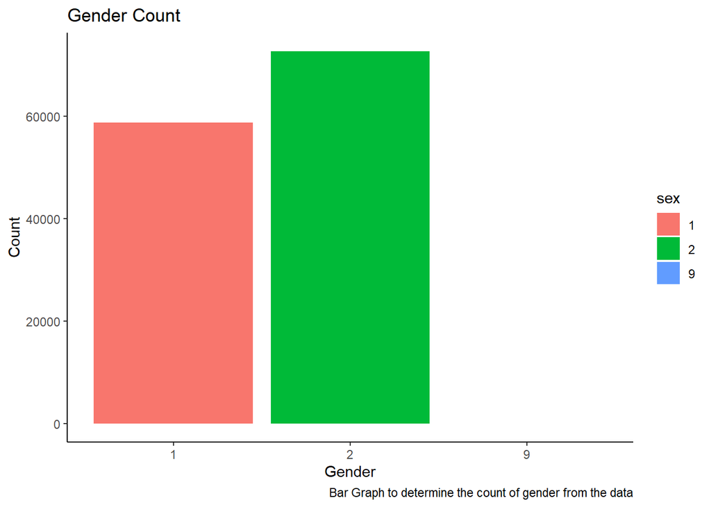

```r
#Plot #1

ggplot(newdata,mapping=aes(x= sex, fill=sex),position='fill')+geom_bar()+theme_classic()+  labs(x='Gender',
       y='Count',
       title='Gender Count',
       caption='Bar Graph to determine the count of gender from the data')+ggsave("plot1.png")
```

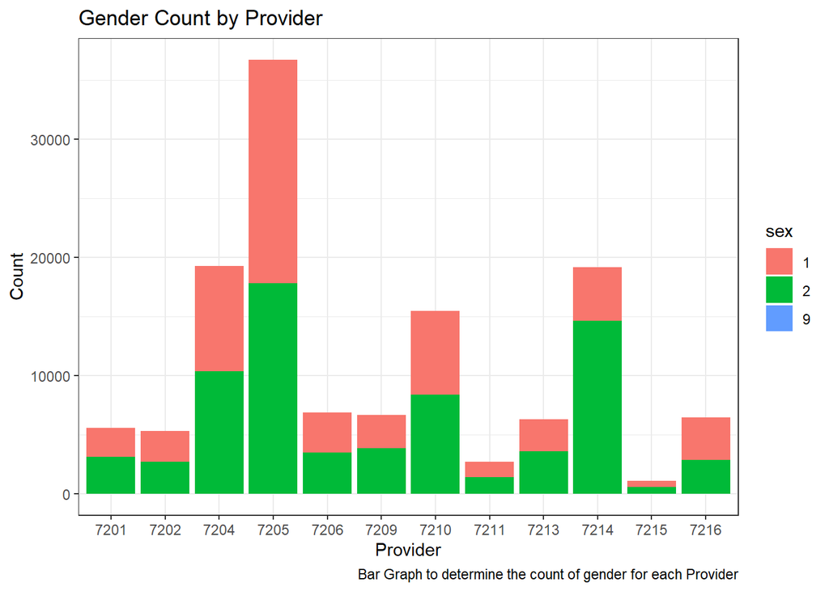

```r
#Plot #2

ggplot(newdata,mapping=aes(x=provider, fill=sex),position='fill')+geom_bar()+theme_bw()+  labs(x='Provider',
       y='Count',
       title='Gender Count by Provider',
       caption='Bar Graph to determine the count of gender for each Provider')+ggsave("plot2.png",dpi = 80)
```

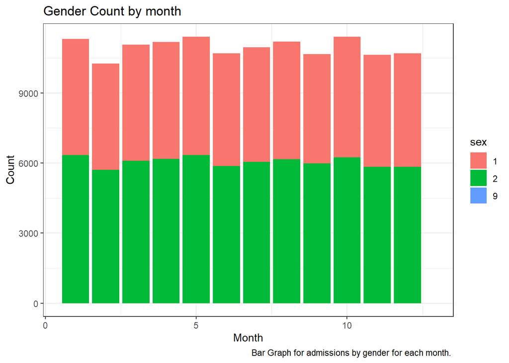

```r
# Plot #3

ggplot(newdata,mapping=aes(x=moa, fill=sex),position='fill')+geom_bar()+theme_bw()+  labs(x='Month',
       y='Count',
       title='Gender Count by month',
       caption='Bar Graph for admissions by gender for each month. ')+ggsave("plot3.png",dpi = 80)
```